# Practical Class: Data Analysis for the Mental Rotation Task

# Instructions

- Download [this zip file](https://michael-franke.github.io/XPLab_2019/handouts/mental_rotation_analysis.zip).
- Download the results file from Stud.IP.
- Open the .Rmd file in RStudio.
- Fill in the code required (ask for help if needed!)
- When you’re done: ‘Knit’ the document (`ctrl/cmd` + `shift` + `K` in RStudio) to produce a HTML file.

# Suggested resources

- [RStudio cheatsheets](https://www.rstudio.com/resources/cheatsheets/).

# Required R packages

- `tidyverse` (or `ggplot2`, `dplyr`, `purrr`, `tibble`)
- `brms`
- `devtools` (for installing `faintr`)
- `rstan`
- `faintr` (install with `devtools`)

Load the required packages and set a seed for the random number generator.

```r
library(tidyverse)

library(rstan)
# set cores to use to the total number of cores (minimally 4)
options(mc.cores = max(parallel::detectCores(), 4))
# save a compiled version of the Stan model file
rstan_options(auto_write = TRUE)

library(brms)

# install faintr with
#install.packages("HDInterval")
#devtools::install_github('michael-franke/bayes_mixed_regression_tutorial/faintr', build_vignettes = TRUE)
library(faintr)


set.seed(123)
```

## Step 1. Read the data and take a glimpse of it.

Use `read_csv()` and `glimpse()`

```r
(mental_rotation <- read_csv("C:/Users/Viviane/Documents/Studium/Cognitive-Science/6.Semester/Experimental-Psychology-Lab/Session_23.05/mrt_results.csv"))
```

```
## # A tibble: 1,620 x 20
##    submission_id    RT   age angle comments correctness education endTime
##            <dbl> <dbl> <dbl> <dbl> <chr>    <chr>       <chr>       <dbl>
##  1          7940  4760    22   150 <NA>     correct     Graduate~ 1.56e12
##  2          7940  2381    22    50 <NA>     correct     Graduate~ 1.56e12
##  3          7940  2650    22   150 <NA>     correct     Graduate~ 1.56e12
##  4          7940  2272    22    50 <NA>     correct     Graduate~ 1.56e12
##  5          7940  2026    22    50 <NA>     correct     Graduate~ 1.56e12
##  6          7940  2386    22   150 <NA>     correct     Graduate~ 1.56e12
##  7          7940  2112    22   150 <NA>     correct     Graduate~ 1.56e12
##  8          7940  2168    22   150 <NA>     incorrect   Graduate~ 1.56e12
##  9          7940  3125    22   150 <NA>     correct     Graduate~ 1.56e12
## 10          7940  2640    22    50 <NA>     correct     Graduate~ 1.56e12
## # ... with 1,610 more rows, and 12 more variables: expected <chr>,
## #   experiment_id <dbl>, gender <chr>, item <dbl>, key_pressed <chr>,
## #   languages <chr>, picture <chr>, startDate <chr>, startTime <dbl>,
## #   timeSpent <dbl>, trial_number <dbl>, trial_type <chr>
```

```r
glimpse(mental_rotation)
```

```
## Observations: 1,620
## Variables: 20
## $ submission_id <dbl> 7940, 7940, 7940, 7940, 7940, 7940, 7940, 7940, ...
## $ RT            <dbl> 4760, 2381, 2650, 2272, 2026, 2386, 2112, 2168, ...
## $ age           <dbl> 22, 22, 22, 22, 22, 22, 22, 22, 22, 22, 22, 22, ...
## $ angle         <dbl> 150, 50, 150, 50, 50, 150, 150, 150, 150, 50, 50...
## $ comments      <chr> NA, NA, NA, NA, NA, NA, NA, NA, NA, NA, NA, NA, ...
## $ correctness   <chr> "correct", "correct", "correct", "correct", "cor...
## $ education     <chr> "Graduated High School", "Graduated High School"...
## $ endTime       <dbl> 1.558597e+12, 1.558597e+12, 1.558597e+12, 1.5585...
## $ expected      <chr> "same", "different", "different", "same", "same"...
## $ experiment_id <dbl> 57, 57, 57, 57, 57, 57, 57, 57, 57, 57, 57, 57, ...
## $ gender        <chr> "female", "female", "female", "female", "female"...
## $ item          <dbl> 15, 15, 15, 15, 13, 13, 13, 14, 14, 14, 13, 14, ...
## $ key_pressed   <chr> "f", "j", "j", "f", "f", "j", "f", "f", "f", "f"...
## $ languages     <chr> "German", "German", "German", "German", "German"...
## $ picture       <chr> "images/practice/15_150_same.jpg", "images/pract...
## $ startDate     <chr> "Thu May 23 2019 09:20:31 GMT+0200 (Mitteleuropä...
## $ startTime     <dbl> 1.558596e+12, 1.558596e+12, 1.558596e+12, 1.5585...
## $ timeSpent     <dbl> 9.6116, 9.6116, 9.6116, 9.6116, 9.6116, 9.6116, ...
## $ trial_number  <dbl> 1, 2, 3, 4, 5, 6, 7, 8, 9, 10, 11, 12, 1, 2, 3, ...
## $ trial_type    <chr> "practice", "practice", "practice", "practice", ...
```

## Step 2. Select only the columns of interest.

Do this with the `select()` command.

```r
selected_data <- select(mental_rotation, submission_id, trial_type, item, expected, correctness, angle, RT)
```

```r
View(selected_data)
```

## Step 3. Change columns to the correct data type.

Use `mutate()`: * `expected` should be a factor (also rename this to `condition`) * `correctness` should be a factor * `angle` should be a factor * `trial_type` should be a factor

```r
selected_data <- selected_data %>% mutate(condition = factor(expected), correctness = factor(correctness), angle = factor(angle), trial_type = factor(trial_type), expected = NULL)
```

## Step 4. Show the data frame.

Check that everything is there and of the correct type.

```r
selected_data
```

```
## # A tibble: 1,620 x 7
##    submission_id trial_type  item correctness angle    RT condition
##            <dbl> <fct>      <dbl> <fct>       <fct> <dbl> <fct>
##  1          7940 practice      15 correct     150    4760 same
##  2          7940 practice      15 correct     50     2381 different
##  3          7940 practice      15 correct     150    2650 different
##  4          7940 practice      15 correct     50     2272 same
##  5          7940 practice      13 correct     50     2026 same
##  6          7940 practice      13 correct     150    2386 different
##  7          7940 practice      13 correct     150    2112 same
##  8          7940 practice      14 incorrect   150    2168 different
##  9          7940 practice      14 correct     150    3125 same
## 10          7940 practice      14 correct     50     2640 same
## # ... with 1,610 more rows
```

```r
str(selected_data)
```

```
## Classes 'spec_tbl_df', 'tbl_df', 'tbl' and 'data.frame': 1620 obs. of  7 variables:
##  $ submission_id: num  7940 7940 7940 7940 7940 7940 7940 7940 7940 7940 ...
##  $ trial_type   : Factor w/ 2 levels "main","practice": 2 2 2 2 2 2 2 2 2 2 ...
##  $ item         : num  15 15 15 15 13 13 13 14 14 14 ...
##  $ correctness  : Factor w/ 2 levels "correct","incorrect": 1 1 1 1 1 1 1 2 1 1 ...
##  $ angle        : Factor w/ 2 levels "50","150": 2 1 2 1 1 2 2 2 2 1 ...
##  $ RT           : num  4760 2381 2650 2272 2026 ...
##  $ condition    : Factor w/ 2 levels "different","same": 2 1 1 2 2 1 2 1 2 2 ...
```

## Step 5. Filter only the ‘main’ trials with correct responses.

Use `filter()`.

```r
correct_data <- selected_data %>% filter(correctness == "correct", trial_type == "main")
```

## Step 6. Make a boxplot of the data.

Show condition (same/different) on the x-axis and RT on the y-axis. Show the different angles in different colors (fill). (use `ggplot()` and `geom_boxplot`)

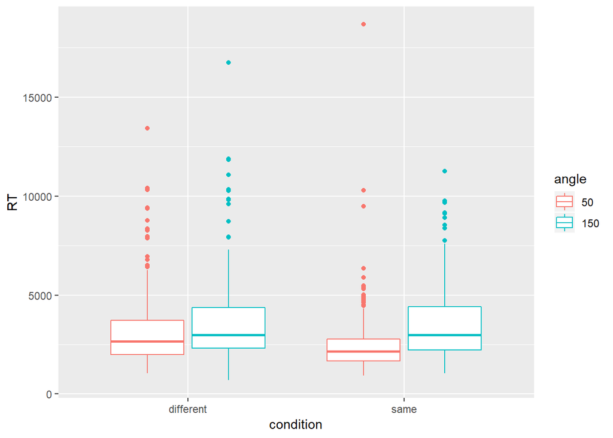

```r
(ggplot(correct_data, aes(condition, RT, colour = angle))+
  geom_boxplot())
```

## Step 7. Remove outliers

Use `filter()` to filter only response times that are in a reasonable range.

```r
(correct_data <- filter(correct_data, RT <= 7000, RT >= 200))
```

```
## # A tibble: 1,106 x 7
##    submission_id trial_type  item correctness angle    RT condition
##            <dbl> <fct>      <dbl> <fct>       <fct> <dbl> <fct>
##  1          7940 main          12 correct     50     2340 same
##  2          7940 main           6 correct     50     2392 same
##  3          7940 main           6 correct     150    2715 different
##  4          7940 main           3 correct     50     2763 same
##  5          7940 main          10 correct     50     2647 different
##  6          7940 main           1 correct     150    3009 same
##  7          7940 main          11 correct     50     2834 different
##  8          7940 main           8 correct     50     2669 same
##  9          7940 main           5 correct     150    2728 different
## 10          7940 main           8 correct     50     3515 different
## # ... with 1,096 more rows
```

## Step 8. Show means for each design cell.

Use `group_by() %>% summarise()`.

```r
(means <- selected_data %>% group_by(condition, angle) %>% summarise(mean = mean(RT)))
```

```
## # A tibble: 4 x 3
## # Groups:   condition [2]
##   condition angle  mean
##   <fct>     <fct> <dbl>
## 1 different 50    3047.
## 2 different 150   3701.
## 3 same      50    2521.
## 4 same      150   3569.
```

## Step 9. Run a bayesian fixed-effects model

Use `brm` to model the response times from angle, condition and angle*condition.

```r
formulaFE = RT ~ angle*condition

(modelFE = brm(
  formula = formulaFE,
  data = correct_data
))
```

```
##  Family: gaussian
##   Links: mu = identity; sigma = identity
## Formula: RT ~ angle * condition
##    Data: correct_data (Number of observations: 1106)
## Samples: 4 chains, each with iter = 2000; warmup = 1000; thin = 1;
##          total post-warmup samples = 4000
##
## Population-Level Effects:
##                        Estimate Est.Error l-95% CI u-95% CI Eff.Sample
## Intercept               2940.02     74.56  2793.55  3084.00       2930
## angle150                 339.79    107.65   126.23   545.15       2386
## conditionsame           -546.80    102.72  -748.32  -343.04       2552
## angle150:conditionsame   509.21    152.62   211.82   804.22       2207
##                        Rhat
## Intercept              1.00
## angle150               1.00
## conditionsame          1.00
## angle150:conditionsame 1.00
##
## Family Specific Parameters:
##       Estimate Est.Error l-95% CI u-95% CI Eff.Sample Rhat
## sigma  1262.51     26.95  1211.33  1315.31       4000 1.00
##
## Samples were drawn using sampling(NUTS). For each parameter, Eff.Sample
## is a crude measure of effective sample size, and Rhat is the potential
## scale reduction factor on split chains (at convergence, Rhat = 1).
```

## Step 10. See how probable the following hypotheses are:

Use `faintr::compare_groups()`

"Responses to ‘same’ trials are faster than responses to ‘different’ trials.

```r
compare_groups(modelFE, higher = list("condition" = "different"), lower = list("condition" = "same"))
```

```
## Outcome of comparing groups:
##  * higher:  condition:different
##  * lower:   condition:same
## Mean 'higher - lower':  292.2
## 95% CI: [ 145 ; 436 ]
## P('higher - lower' > 0):  1
```

"Responses to ‘50 degree’ trials are faster than responses to ‘150 degree’ trials.

```r
faintr::compare_groups(modelFE, list(angle = "150"), list(angle = "50"))
```

```
## Outcome of comparing groups:
##  * higher:  angle:150
##  * lower:   angle:50
## Mean 'higher - lower':  594.4
## 95% CI: [ 445.1 ; 744.6 ]
## P('higher - lower' > 0):  1
```

“Angle matters more than same/different for response times”. (In other words, when the angle is lower but the objects are ‘different’, people are still faster than when the angle is higher but the objects are the ‘same’.)

```r
(angle_lower <- compare_groups(modelFE, higher = list("angle" = "150", "condition" = "same"), lower = list("angle" = "50", "condition" = "different")))
```

```
## Outcome of comparing groups:
##  * higher:  angle:150 condition:same
##  * lower:   angle:50 condition:different
## Mean 'higher - lower':  302.2
## 95% CI: [ 103.6 ; 530.3 ]
## P('higher - lower' > 0):  0.9968
```

## Step 11. Run the model again, but this time include random effects

Include random by-item intercepts (`+ (1|item)`).

```r
formulaME = RT ~ angle*condition + (1|item)

(modelME = brm(
  formula = formulaME,
  data = correct_data
))
```

```
##  Family: gaussian
##   Links: mu = identity; sigma = identity
## Formula: RT ~ angle * condition + (1 | item)
##    Data: correct_data (Number of observations: 1106)
## Samples: 4 chains, each with iter = 2000; warmup = 1000; thin = 1;
##          total post-warmup samples = 4000
##
## Group-Level Effects:
## ~item (Number of levels: 12)
##               Estimate Est.Error l-95% CI u-95% CI Eff.Sample Rhat
## sd(Intercept)   222.90     77.42   105.07   408.46       1217 1.00
##
## Population-Level Effects:
##                        Estimate Est.Error l-95% CI u-95% CI Eff.Sample
## Intercept               2945.09     97.91  2753.09  3140.70       2042
## angle150                 325.42    105.99   121.57   540.20       3144
## conditionsame           -554.83    102.51  -752.86  -344.99       3289
## angle150:conditionsame   544.51    150.21   244.51   834.95       2836
##                        Rhat
## Intercept              1.00
## angle150               1.00
## conditionsame          1.00
## angle150:conditionsame 1.00
##
## Family Specific Parameters:
##       Estimate Est.Error l-95% CI u-95% CI Eff.Sample Rhat
## sigma  1248.75     26.70  1197.49  1302.51       4000 1.00
##
## Samples were drawn using sampling(NUTS). For each parameter, Eff.Sample
## is a crude measure of effective sample size, and Rhat is the potential
## scale reduction factor on split chains (at convergence, Rhat = 1).
```

## Step 12. Check the same hypotheses for the mixed effects model

```r
compare_groups(modelME, higher = list("condition" = "different"), lower = list("condition" = "same"))
```

```
## Outcome of comparing groups:
##  * higher:  condition:different
##  * lower:   condition:same
## Mean 'higher - lower':  282.6
## 95% CI: [ 134.8 ; 430.9 ]
## P('higher - lower' > 0):  1
```

```r
faintr::compare_groups(modelME, list(angle = "150"), list(angle = "50"))
```

```
## Outcome of comparing groups:
##  * higher:  angle:150
##  * lower:   angle:50
## Mean 'higher - lower':  597.7
## 95% CI: [ 438.8 ; 739.1 ]
## P('higher - lower' > 0):  1
```

```r
(angle_lower <- compare_groups(modelME, higher = list("angle" = "150", "condition" = "same"), lower = list("angle" = "50", "condition" = "different")))
```

```
## Outcome of comparing groups:
##  * higher:  angle:150 condition:same
##  * lower:   angle:50 condition:different
## Mean 'higher - lower':  315.1
## 95% CI: [ 102.3 ; 530.6 ]
## P('higher - lower' > 0):  0.998
```

## Step 13. Conclude

There are three different hypotheses we are investigating: H1. The condition of the trial matters for the response time: ‘same’ trials are faster than ‘different’ trials H2. The angle matters for the response time: ‘50 degree’ trials are faster than ‘150 degree’ trials H3. Angle matters more than the condition of the trial: when the angle is lower and the objects are ‘different’, people are faster then when the angle is higher and the objects are ‘same’

We created two different models, one regressing the dependent variable response time against the independent variables angle (‘50’, ‘150’) and condition (‘same’, ‘different’) and including their interaction and the other one also taking random ‘by-item’ effects into account. We are expecting that there is a by-item variation, meaning that for some item the response time might be faster, than for another regardless the condition and angle.

By looking at the 95-credible intervals for both models we see that there is a high posterior probability that the response time for 150 degree angle is higher than for 50 degree angle, as well as that the response time for the ‘same’ condition is shorter than for the ‘different’ condition. And it also seems as if angle matters more than the condition of the trial.

To conclude, all our three hypotheses have a very certain posterior probability, given our data, our models and prior beliefs.

End of sheet.